# Seguimiento6 - PROMSACE

Hernan Nuñez

8/8/2020

## Objetivo del trabajo

La finalidad de este trabajo es encontrar asociaciones entre categorias de variables y identificar grupos de individuos con perfil similar en sus respuestas a las preguntas.

## Librerias

Paquetes usados para el R

```r
library(tidyverse)
library(readxl)
library(lubridate)
```

```r
library(ca)
library(gplots)
library(factoextra)
library(FactoMineR)
library(GGally)
library(knitr)
library(corrplot)
```

## Base de datos

Vista parcial de la base de datos de la encuesta

```r
bbdd <- read_excel("promsace 6agosto6pm.xlsx",
    sheet = "Base de datos", range = "A3:AA3997",
    col_types = c("date", "text", "text", "text",
        "text", "text", "text", "text", "text",
        "text", "text", "text", "text", "text",
        "text", "text", "text", "text", "text",
        "text", "text", "text", "text", "text",
        "text", "text", "text"))
#-------------------

bbdd$`Recursos humanos` <- factor(bbdd$`Recursos humanos`, levels = c("Recursos humanos (capacitación, selección de personal, liquidación de beneficios, control de asistencia, etc.)", "No Aplica", "Sin Respuesta"), labels = c("Si", "No", "Sin Respuesta"))

#-------------------

bbdd$Abastecimiento <- factor(bbdd$Abastecimiento, levels = c("Abastecimiento (contratación de proveedores, patrimonio, términos de referencia, etc.)", "No Aplica", "Sin Respuesta"), labels = c("Si", "No", "Sin Respuesta"))

#-------------------

bbdd$`Presupuesto público` <- factor(bbdd$`Presupuesto público`, levels = c("Presupuesto público (PIA, PIM, PPR, certificación, devengado, etc.)", "No Aplica", "Sin Respuesta"), labels = c("Si", "No", "Sin Respuesta"))

#-------------------

bbdd$Tesorería <- factor(bbdd$Tesorería, levels = c("Tesorería (viajes y viáticos, caja única, caja chica, etc.)", "No Aplica", "Sin Respuesta"), labels = c("Si", "No", "Sin Respuesta"))

#-------------------

bbdd$Contabilidad <- factor(bbdd$Contabilidad, levels = c("Contabilidad (rendición de cuentas, Cuenta General de la República, estados financieros, etc.)", "No Aplica", "Sin Respuesta"), labels = c("Si", "No", "Sin Respuesta"))

#-------------------

bbdd$Control <- factor(bbdd$Control, levels = c("Control (previo, simultáneo, concurrente, auditorías externas etc.)", "No Aplica", "Sin Respuesta"), labels = c("Si", "No", "Sin Respuesta"))

#-------------------

bbdd$`Inversión pública` <- factor(bbdd$`Inversión pública`, levels = c("Inversión pública (perfil, formulación, evaluación, expediente técnico, banco de inversiones, etc.)", "No Aplica", "Sin Respuesta"), labels = c("Si", "No", "Sin Respuesta"))

#-------------------

bbdd$`Planeamiento estratégico` <- factor(bbdd$`Planeamiento estratégico`, levels = c("Planeamiento estratégico (POI, PEI, PDC, PESEM)", "No Aplica", "Sin Respuesta"), labels = c("Si", "No", "Sin Respuesta"))

#-------------------

bbdd$`Modernización de la Gestión Pública` <- factor(bbdd$`Modernización de la Gestión Pública`, levels = c("Modernización de la Gestión Pública (estructura y funcionamiento, procedimientos administrativos, procesos, gobierno abierto, etc.)", "No Aplica", "Sin Respuesta"), labels = c("Si", "No", "Sin Respuesta"))

#-------------------

bbdd$`No sé` <- factor(bbdd$`No sé`, levels = c("No sé", "No Aplica", "Sin Respuesta"), labels = c("Si", "No", "Sin Respuesta"))

#-------------------

bbdd$Otro <- factor(bbdd$Otro,levels = c("Si", "No", "Sin Respuesta"))

#-------------------

bbdd$`Cambiar el marco normativo` <- factor(bbdd$`Cambiar el marco normativo`, levels = c("Cambiar el marco normativo", "No Aplica", "Sin Respuesta"), labels = c("Si", "No", "Sin Respuesta"))

#-------------------

bbdd$`Potenciar conocimientos y habilidades de los servidores civiles` <- factor(bbdd$`Potenciar conocimientos y habilidades de los servidores civiles`, levels = c("Potenciar conocimientos y habilidades de los servidores civiles", "No Aplica", "Sin Respuesta"), labels = c("Si", "No", "Sin Respuesta"))

#-------------------

bbdd$`Articular labores entre áreas` <- factor(bbdd$`Articular labores entre áreas`, levels = c("Articular labores entre áreas", "No Aplica", "Sin Respuesta"), labels = c("Si", "No", "Sin Respuesta"))

#-------------------

bbdd$`Mejorar los sistemas informáticos y sistematizar procesos` <- factor(bbdd$`Mejorar los sistemas informáticos y sistematizar procesos`, levels = c("Mejorar los sistemas informáticos y sistematizar procesos", "No Aplica", "Sin Respuesta"), labels = c("Si", "No", "Sin Respuesta"))

#-------------------

bbdd$`Mejorar la coordinación con el ente rector y otras instituciones` <- factor(bbdd$`Mejorar la coordinación con el ente rector y otras instituciones`, levels = c("Mejorar la coordinación con el ente rector y otras instituciones", "No Aplica", "Sin Respuesta"), labels = c("Si", "No", "Sin Respuesta"))

#-------------------

bbdd$lista <- factor(bbdd$lista, levels = c("254102633", "256377828", "262814520", "262814761", "262814235"), labels = c("Web Link 1", "Piloto", "Lista 2", "Lista 1", "Lista 3"))

#-------------------

bbdd$Identificado <- factor(bbdd$Identificado , levels = c("Identificado", "No Identificado", "Viciado", "No Aplica", "Sin Respuesta"))

#-------------------

bbdd$Priorizado <- factor(bbdd$Priorizado , levels = c("Si", "No", "Viciado", "No Aplica", "Sin Respuesta"))

#--------------------

bbdd$`Nivel de gobierno` <- factor(bbdd$`Nivel de gobierno` , levels = c("Nacional", "Regional", "Local", "Viciado", "No Identificado", "No Aplica", "Sin Respuesta"))

#-------------------

bbdd$`Organo de pertenencia` <- factor(bbdd$`Organo de pertenencia`, levels = c("Órgano de Apoyo (recursos humanos, administración, tecnologías de la información, otros)", "Órgano de Asesoría (jurídica, planeamiento, presupuesto, otros)", "Órgano de Línea", "Otros", "Sin Respuesta"), labels = c("apoyo", "asesoria", "linea", "Otros","Sin Respuesta"))

#--------------------

bbdd$Sexo <- factor(bbdd$Sexo , levels = c("Hombre", "Mujer", "Sin Respuesta"))

#-------------------

bbdd$`Años trabajando en el Estado` <- factor(bbdd$`Años trabajando en el Estado`, levels = c("Menos de dos años", "De dos a cinco años", "De seis a diez años", "Más de diez años", "Sin Respuesta"), labels = c("[0 - 2>", "[2 - 5]", "[6 - 10]", "[11 a más>", "Sin Respuesta"))

#-------------------

bbdd$año <- year(bbdd$Fecha)

#-------------------

bbdd$mes <- month(bbdd$Fecha)

#-------------------

bbdd$dia <- day(bbdd$Fecha)

#-------------------

bbdd$hora <- hour(bbdd$Fecha)

#-------------------

bbdd$minuto <- min(bbdd$Fecha)

#-------------------

bbdd$segundo <- second(bbdd$Fecha)

#-------------------

bbdd$dia_de_la_semana <- wday(bbdd$Fecha, label = TRUE)

#------------------

bbdd$semana <- week(bbdd$Fecha)

head(bbdd)
```

```
## # A tibble: 6 x 35
##   Fecha               lista `Traba administ~ `Recursos human~ Abastecimiento
##   <dttm>              <fct> <chr>            <fct>            <fct>
## 1 2020-02-28 10:16:04 Web ~ x                No               Si
## 2 2020-02-28 11:03:11 Web ~ Prueba           No               No
## 3 2020-02-28 11:29:31 Web ~ gbfghjhjhj       Sin Respuesta    Sin Respuesta
## 4 2020-02-28 12:01:00 Web ~ prueba GYA       No               Si
## 5 2020-02-28 13:41:09 Web ~ Que tengo que h~ No               No
## 6 2020-02-28 13:41:35 Web ~ Demora ( pago d~ No               No
## # ... with 30 more variables: `Presupuesto público` <fct>, Tesorería <fct>,
## #   Contabilidad <fct>, Control <fct>, `Inversión pública` <fct>, `Planeamiento
## #   estratégico` <fct>, `Modernización de la Gestión Pública` <fct>, `No
## #   sé` <fct>, Otro <fct>, `Cambiar el marco normativo` <fct>, `Potenciar
## #   conocimientos y habilidades de los servidores civiles` <fct>, `Articular
## #   labores entre áreas` <fct>, `Mejorar los sistemas informáticos y
## #   sistematizar procesos` <fct>, `Mejorar la coordinación con el ente rector y
## #   otras instituciones` <fct>, `Entidad publica` <chr>, Identificado <fct>,
## #   Priorizado <fct>, `Nivel de gobierno` <fct>, `Organo de pertenencia` <fct>,
## #   Sexo <fct>, `Años trabajando en el Estado` <fct>, completa <chr>,
## #   año <dbl>, mes <dbl>, dia <int>, hora <int>, minuto <dttm>, segundo <dbl>,
## #   dia_de_la_semana <ord>, semana <dbl>
```

## Formato de datos

Las variables que tomaremos para el analisis seran las que provienen de la pregunta 2 y la pregunta 3 del cuestionario debido a que se predeciran las variables lista, nivel de gobierno, organo de pertenencia, sexo y años trabajando para el estado.

```r
bbdd.activa <- bbdd[, 4:19]
head(bbdd.activa)
```

```
## # A tibble: 6 x 16
##   `Recursos human~ Abastecimiento `Presupuesto pú~ Tesorería Contabilidad
##   <fct>            <fct>          <fct>            <fct>     <fct>
## 1 No               Si             No               No        No
## 2 No               No             No               No        No
## 3 Sin Respuesta    Sin Respuesta  Sin Respuesta    Sin Resp~ Sin Respues~
## 4 No               Si             No               No        No
## 5 No               No             No               No        No
## 6 No               No             No               Si        Si
## # ... with 11 more variables: Control <fct>, `Inversión pública` <fct>,
## #   `Planeamiento estratégico` <fct>, `Modernización de la Gestión
## #   Pública` <fct>, `No sé` <fct>, Otro <fct>, `Cambiar el marco
## #   normativo` <fct>, `Potenciar conocimientos y habilidades de los servidores
## #   civiles` <fct>, `Articular labores entre áreas` <fct>, `Mejorar los
## #   sistemas informáticos y sistematizar procesos` <fct>, `Mejorar la
## #   coordinación con el ente rector y otras instituciones` <fct>
```

## Resumen de los datos

```r
summary(bbdd.activa)
```

```
##       Recursos humanos       Abastecimiento    Presupuesto público
##  Si           :1216    Si           : 718   Si           : 373
##  No           :2538    No           :3036   No           :3381
##  Sin Respuesta: 240    Sin Respuesta: 240   Sin Respuesta: 240
##          Tesorería           Contabilidad           Control
##  Si           : 255   Si           : 129   Si           : 217
##  No           :3499   No           :3625   No           :3537
##  Sin Respuesta: 240   Sin Respuesta: 240   Sin Respuesta: 240
##      Inversión pública  Planeamiento estratégico
##  Si           : 171    Si           : 264
##  No           :3583    No           :3490
##  Sin Respuesta: 240    Sin Respuesta: 240
##  Modernización de la Gestión Pública           No sé                 Otro
##  Si           :1512                  Si           : 212   Si           : 444
##  No           :2242                  No           :3542   No           :3310
##  Sin Respuesta: 240                  Sin Respuesta: 240   Sin Respuesta: 240
##  Cambiar el marco normativo
##  Si           : 713
##  No           :2985
##  Sin Respuesta: 296
##  Potenciar conocimientos y habilidades de los servidores civiles
##  Si           :1503
##  No           :2195
##  Sin Respuesta: 296
##  Articular labores entre áreas
##  Si           :1250
##  No           :2448
##  Sin Respuesta: 296
##  Mejorar los sistemas informáticos y sistematizar procesos
##  Si           :1766
##  No           :1932
##  Sin Respuesta: 296
##  Mejorar la coordinación con el ente rector y otras instituciones
##  Si           : 863
##  No           :2835
##  Sin Respuesta: 296
```

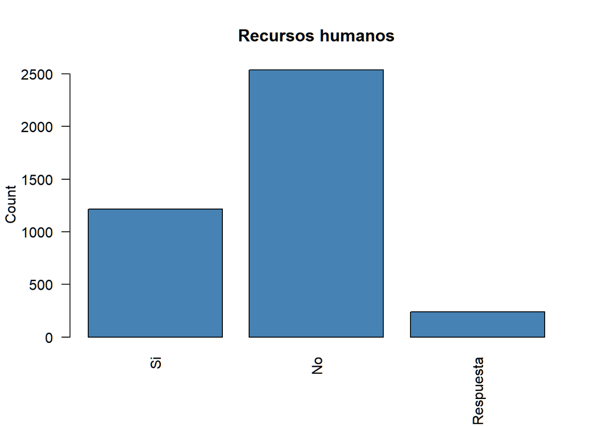

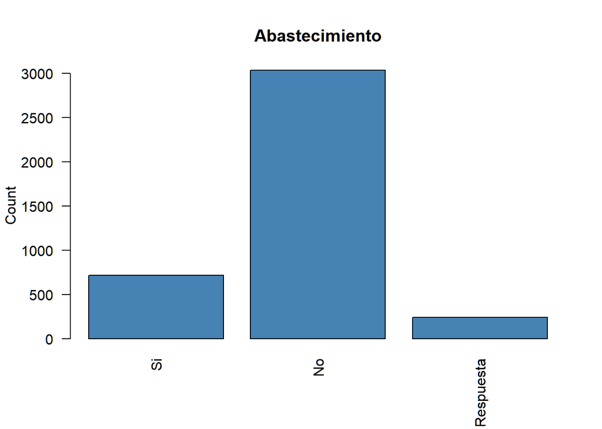

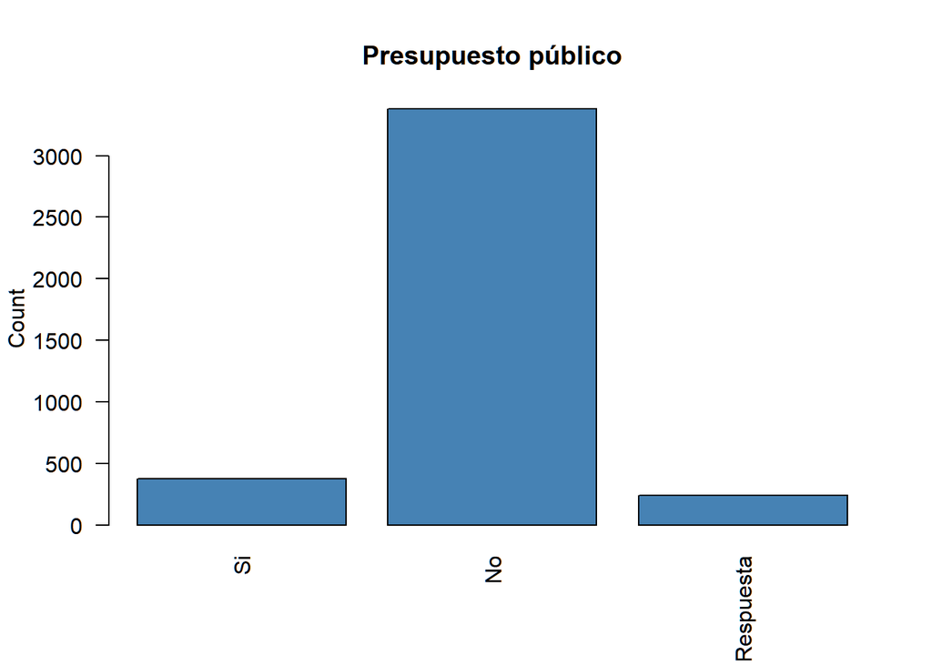

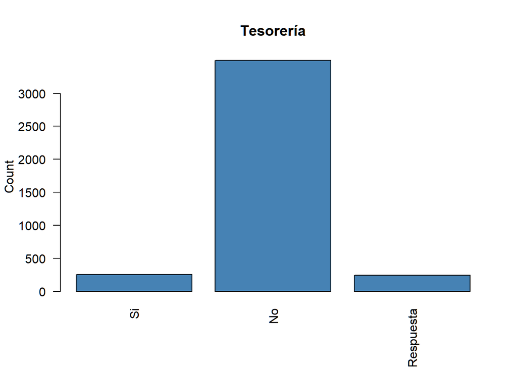

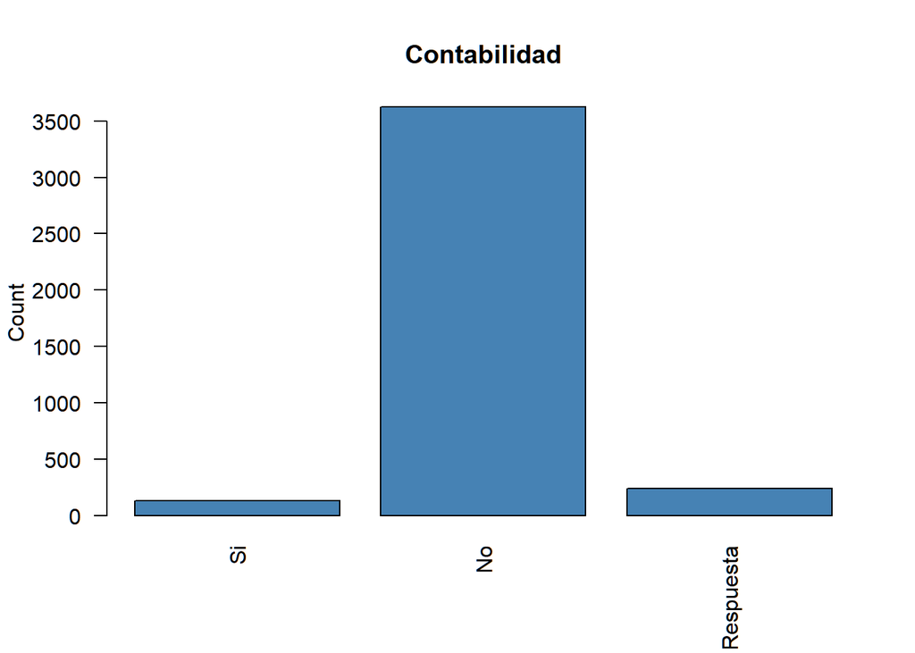

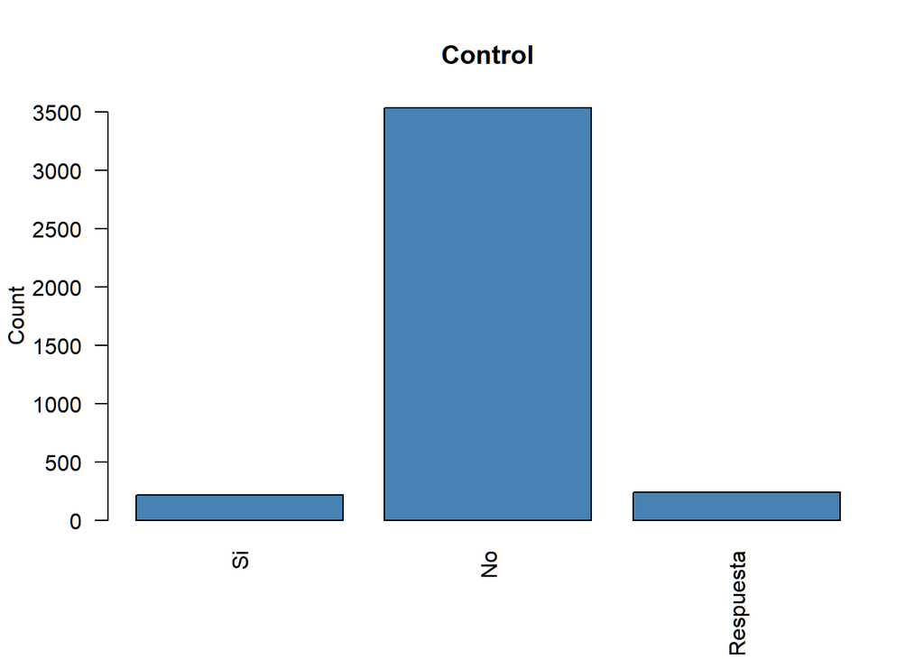

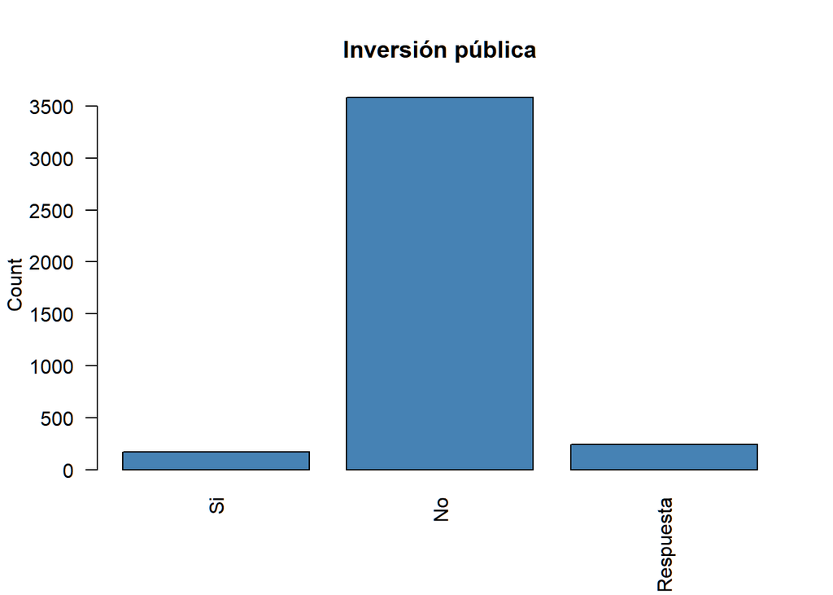

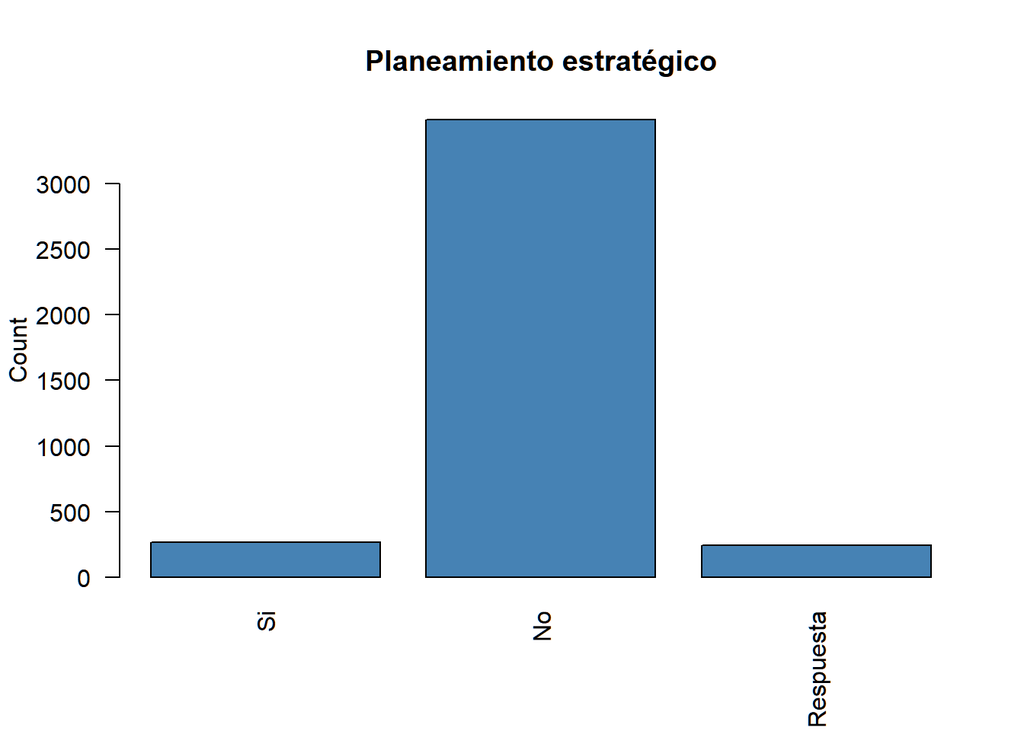

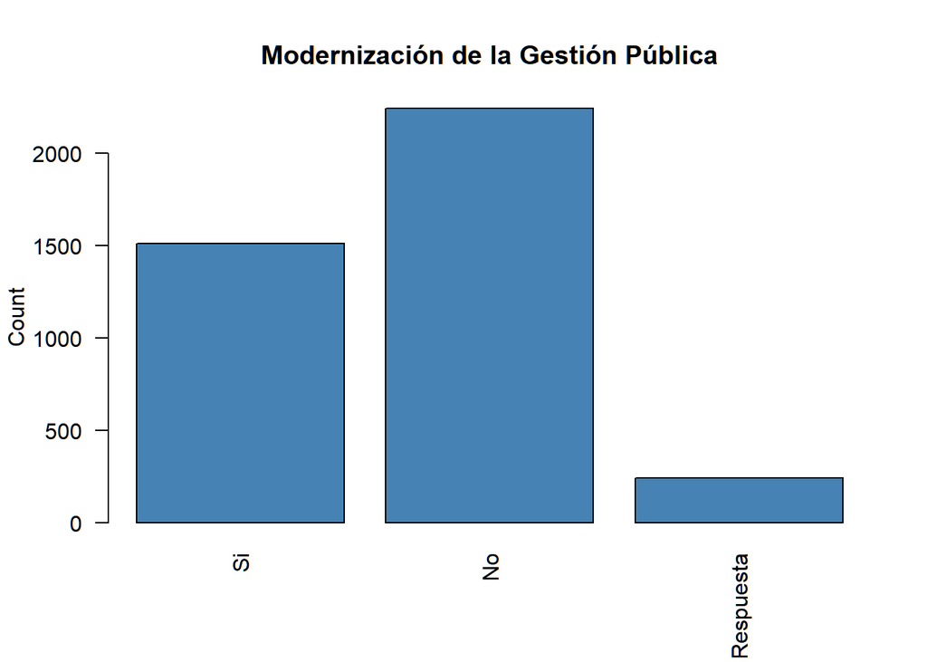

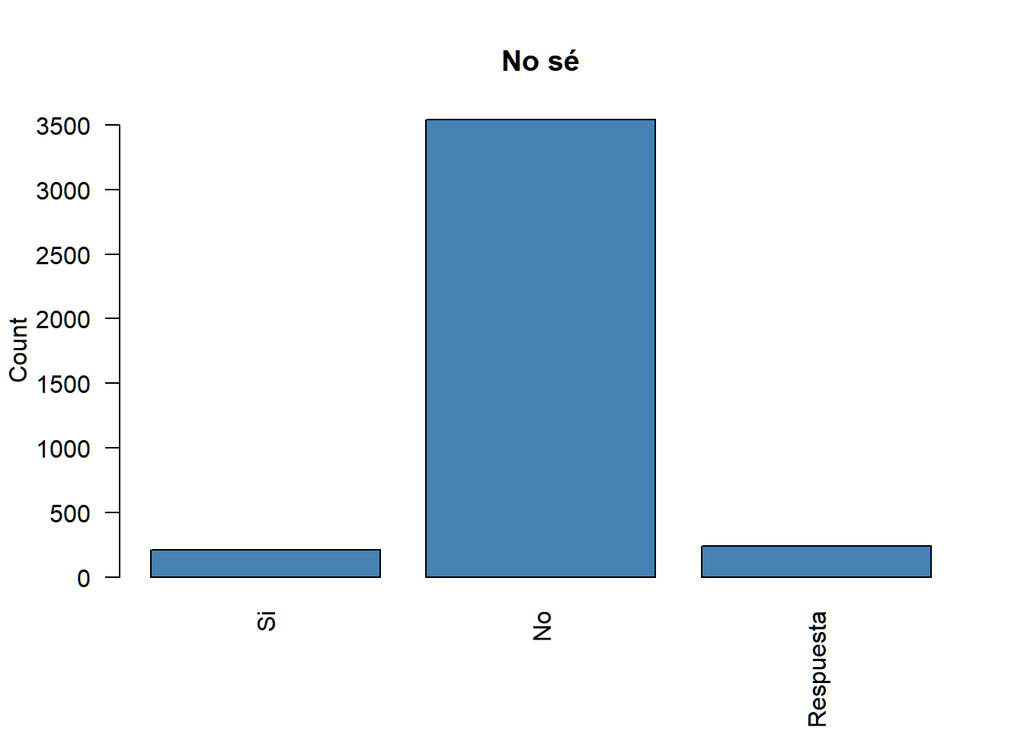

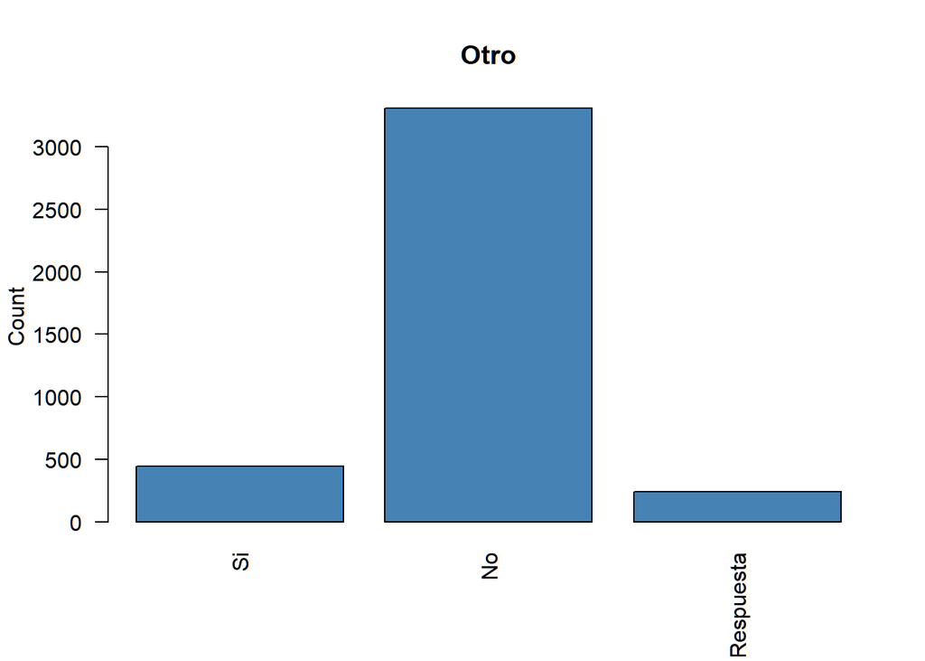

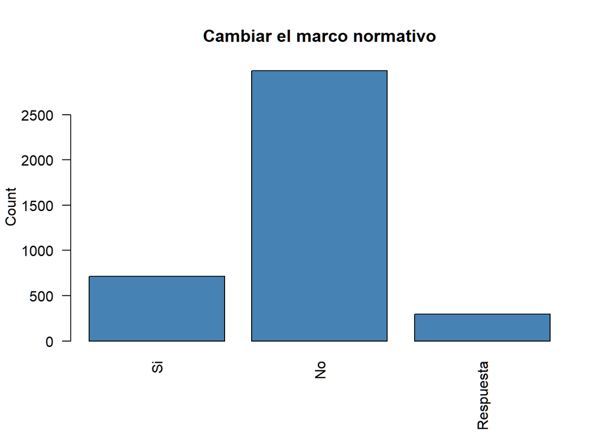

[4 more figures not shown]

```r
for (i in 1:16) {
plot(bbdd.activa[,i], main=colnames(bbdd.activa)[i],
ylab = "Count", col="steelblue", las = 2)
}
```

No hay ninguna variable cuya mayoria haya marcado “si”.

Las variables “recursos humanos” “modernizacion de la gestion publica”, de la pregunta 2 y “Potenciar conocimientos y habilidades de los servidores civiles”, “Articular labores entre áreas”, “Mejorar los sistemas informáticos y sistematizar procesos” de la pregunta 3 son los que mas respuestas afirmativas se obtuvieron por parte de los encuestados.

Si se encuentran categorias de frecuencia muy baja entonces se sugiere quitar la variable respectiva para el analisis.

Lo primero que se hara sera trabajar solo con las 5 variables arriba mencionadas, luego eliminaremos todas las filas que incluyan a un sin respuesta.

## Base de datos de trabajo

```r
bbdd.activa.rem <- bbdd.activa %>%
    select(`Recursos humanos`, `Modernización de la Gestión Pública`, `Potenciar conocimientos y habilidades de los servidores civiles`, `Articular labores entre áreas`, `Mejorar los sistemas informáticos y sistematizar procesos`)

bbdd.activa.rem <- bbdd.activa.rem %>%
    filter(`Recursos humanos` != "Sin Respuesta")

bbdd.activa.rem <- bbdd.activa.rem %>%
    filter(`Potenciar conocimientos y habilidades de los servidores civiles` != "Sin Respuesta")

#-------------------

bbdd.activa.rem$`Recursos humanos` <- factor(bbdd.activa.rem$`Recursos humanos`, levels = c("Si", "No"))

#-------------------

bbdd.activa.rem$`Modernización de la Gestión Pública` <- factor(bbdd.activa.rem$`Modernización de la Gestión Pública`, levels = c("Si", "No"))

#-------------------

bbdd.activa.rem$`Potenciar conocimientos y habilidades de los servidores civiles` <- factor(bbdd.activa.rem$`Potenciar conocimientos y habilidades de los servidores civiles`, levels = c("Si", "No"))

#-------------------

bbdd.activa.rem$`Articular labores entre áreas` <- factor(bbdd.activa.rem$`Articular labores entre áreas`, levels = c("Si", "No"))

#-------------------

bbdd.activa.rem$`Mejorar los sistemas informáticos y sistematizar procesos` <- factor(bbdd.activa.rem$`Mejorar los sistemas informáticos y sistematizar procesos`, levels = c("Si", "No"))

head(bbdd.activa.rem)
```

```
## # A tibble: 6 x 5
##   `Recursos human~ `Modernización ~ `Potenciar cono~ `Articular labo~
##   <fct>            <fct>            <fct>            <fct>
## 1 No               No               Si               No
## 2 No               No               No               No
## 3 No               No               Si               No
## 4 No               Si               No               Si
## 5 No               No               No               No
## 6 Si               No               No               Si
## # ... with 1 more variable: `Mejorar los sistemas informáticos y sistematizar
## #   procesos` <fct>
```

## Resumen de datos de trabajo

```r
summary(bbdd.activa.rem)
```

```
##  Recursos humanos Modernización de la Gestión Pública
##  Si:1202          Si:1500
##  No:2496          No:2198
##  Potenciar conocimientos y habilidades de los servidores civiles
##  Si:1503
##  No:2195
##  Articular labores entre áreas
##  Si:1250
##  No:2448
##  Mejorar los sistemas informáticos y sistematizar procesos
##  Si:1766
##  No:1932
```

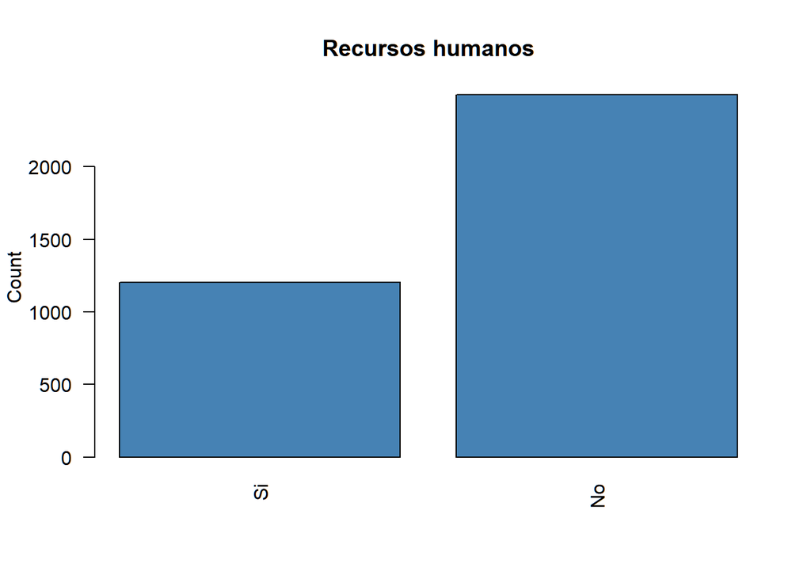

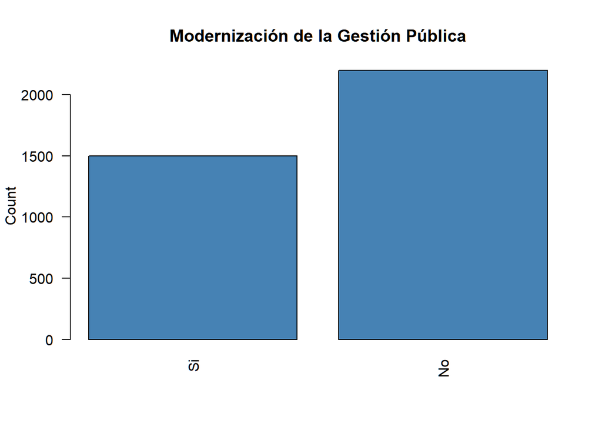

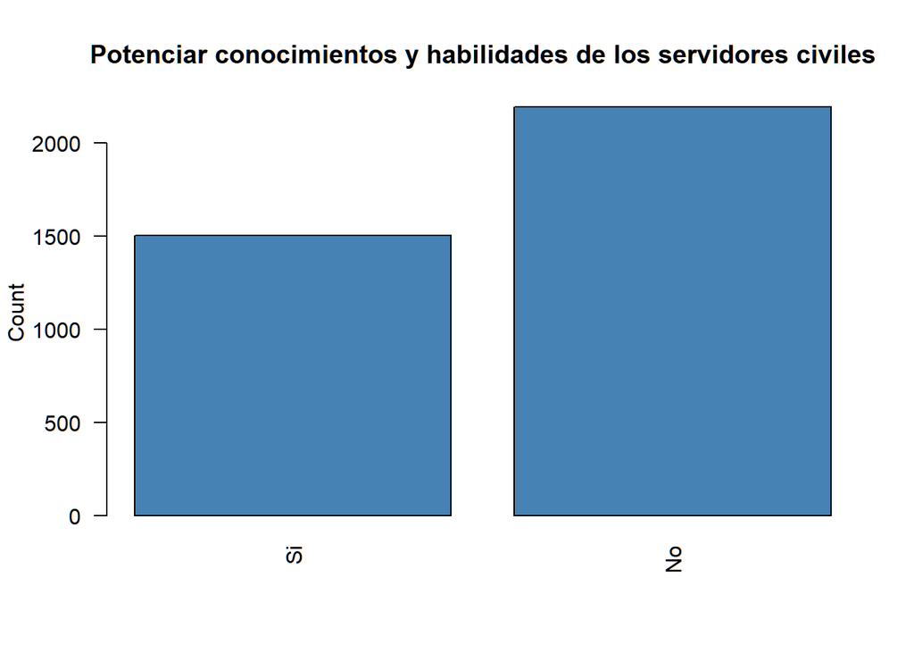

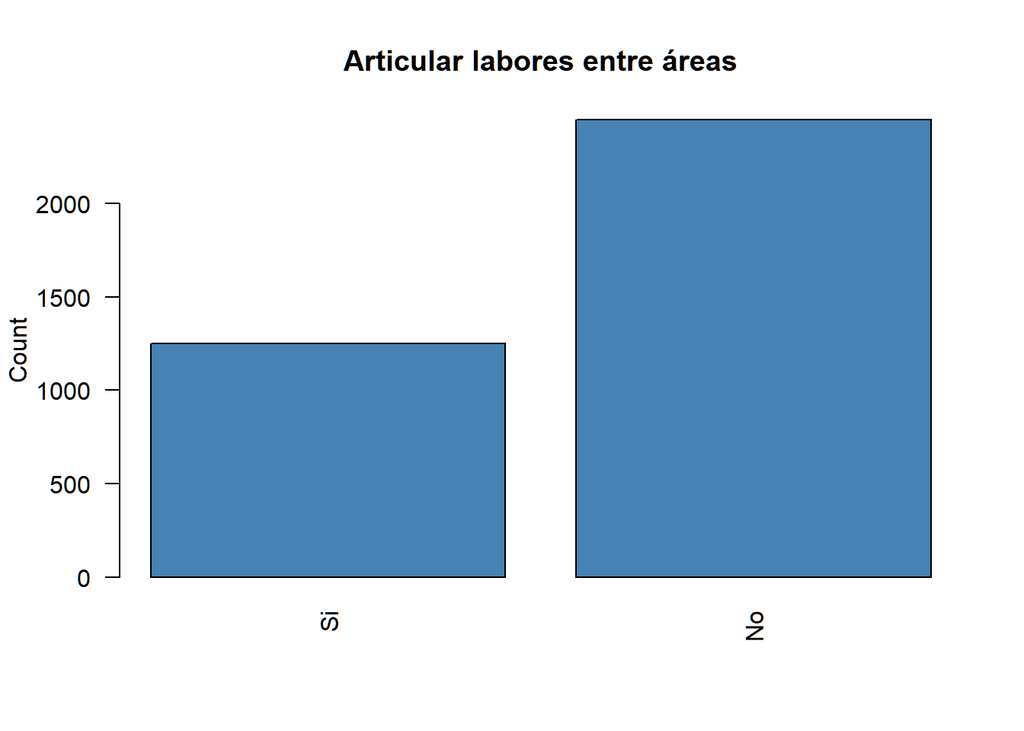

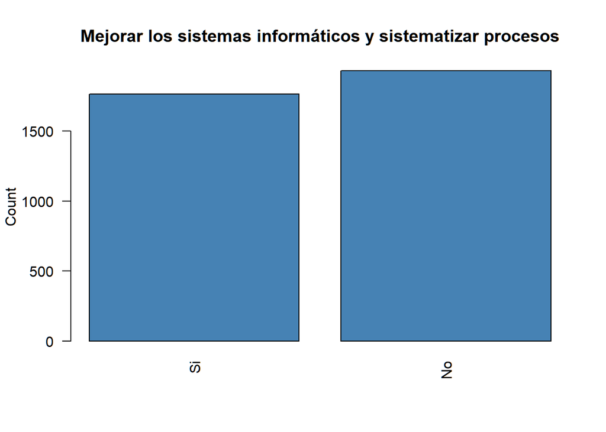

```r
for (i in 1:5) {
plot(bbdd.activa.rem[,i], main=colnames(bbdd.activa.rem)[i],
ylab = "Count", col="steelblue", las = 2)
}
```

Sin contar a los que no respondieron la pregunta 2 y la pregunta 3 vemos que la variable “mejorar los sistemas informaticos y sistematizar procesos” concentra una mayor cantidad de respuestas afirmativas con respecto a las demas variables.

## Análisis MCA

```r
res.mca <- MCA(bbdd.activa.rem, graph = FALSE)
print(res.mca)
```

```
## **Results of the Multiple Correspondence Analysis (MCA)**
## The analysis was performed on 3698 individuals, described by 5 variables
## *The results are available in the following objects:
##
##    name              description
## 1  "$eig"            "eigenvalues"
## 2  "$var"            "results for the variables"
## 3  "$var$coord"      "coord. of the categories"
## 4  "$var$cos2"       "cos2 for the categories"
## 5  "$var$contrib"    "contributions of the categories"
## 6  "$var$v.test"     "v-test for the categories"
## 7  "$ind"            "results for the individuals"
## 8  "$ind$coord"      "coord. for the individuals"
## 9  "$ind$cos2"       "cos2 for the individuals"
## 10 "$ind$contrib"    "contributions of the individuals"
## 11 "$call"           "intermediate results"
## 12 "$call$marge.col" "weights of columns"
## 13 "$call$marge.li"  "weights of rows"
```

## Atovalores/Varianzas

```r
eig.val <- get_eigenvalue(res.mca)
print(eig.val)
```

```
##       eigenvalue variance.percent cumulative.variance.percent
## Dim.1  0.2726671         27.26671                    27.26671
## Dim.2  0.2436329         24.36329                    51.63000
## Dim.3  0.1943629         19.43629                    71.06630
## Dim.4  0.1782112         17.82112                    88.88742
## Dim.5  0.1111258         11.11258                   100.00000
```

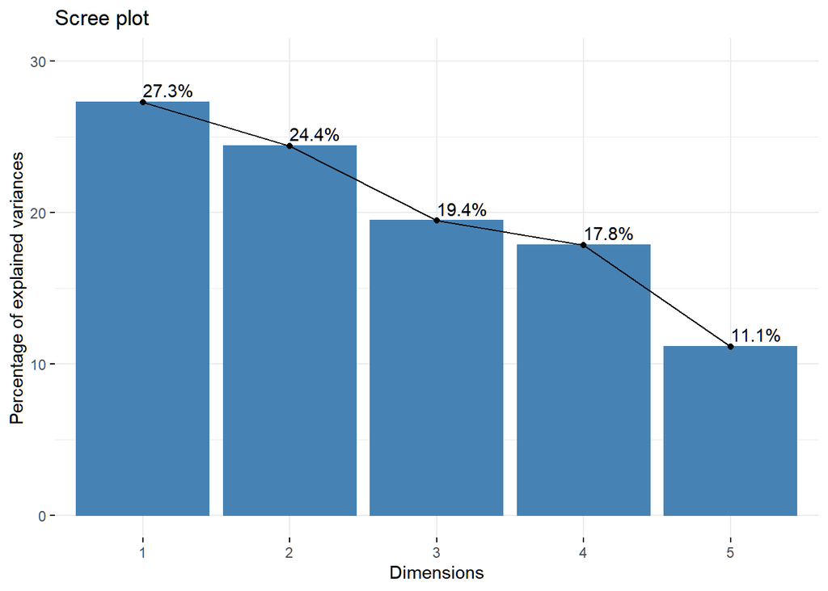

```r
fviz_screeplot(res.mca, addlabels = TRUE, ylim = c(0, 30))
```

Trabajaremos con dos dimensiones porque explican gran cantidad de informacion.

## Graficos

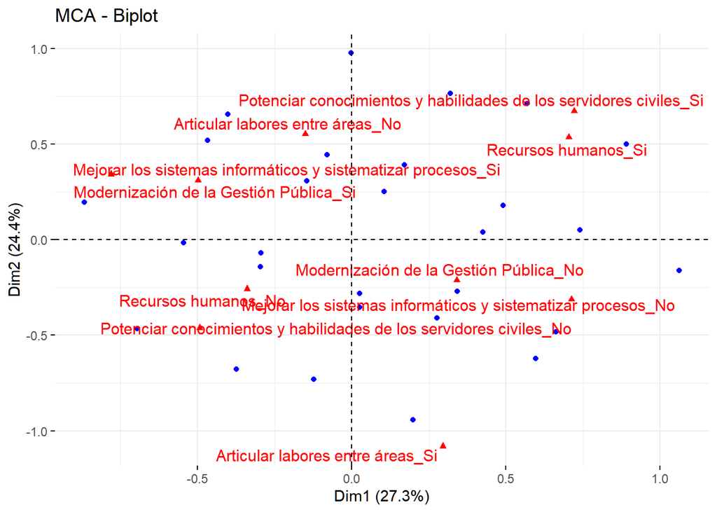

```r
fviz_mca_biplot(res.mca, label = "var", repel = TRUE, ggtheme = theme_minimal())
```

Los puntos cercanos representan individuos similares al igual que los triangulos cercanos.

## Graficos de variables

```r
var <- get_mca_var(res.mca)
var
```

```
## Multiple Correspondence Analysis Results for variables
##  ===================================================
##   Name       Description
## 1 "$coord"   "Coordinates for categories"
## 2 "$cos2"    "Cos2 for categories"
## 3 "$contrib" "contributions of categories"
```

### Correlacion entre variables y dimensiones principales

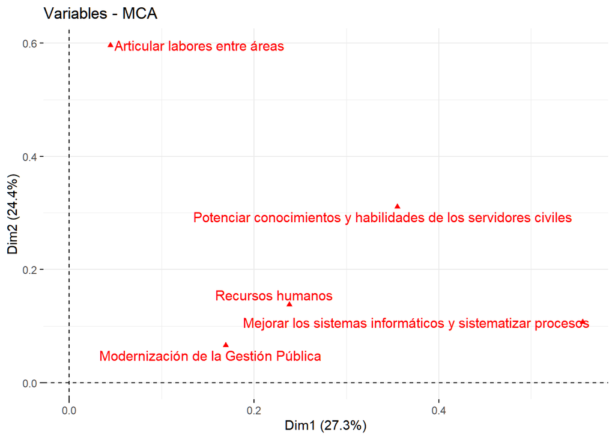

```r
fviz_mca_var(res.mca, choice = "mca.cor", repel = TRUE, ggtheme = theme_minimal())
```

La correlacion al cuadrado entre las variables y las dimensiones se utilizan como coordenadas.

La variable “mejorar los sistemas informaticos y sistematizar procesos” esta mas correlacionada con la dimension 1 y la variable “articular labores entre areas” esta mas correlacionada con la dimension 2

### coordenadas de las categorias

```r
var$coord
```

```
##                                                                         Dim 1
## Recursos humanos_Si                                                 0.7031576
## Recursos humanos_No                                                -0.3386200
## Modernización de la Gestión Pública_Si                             -0.4982528
## Modernización de la Gestión Pública_No                              0.3400270
## Potenciar conocimientos y habilidades de los servidores civiles_Si  0.7204209
## Potenciar conocimientos y habilidades de los servidores civiles_No -0.4932996
## Articular labores entre áreas_Si                                    0.2962560
## Articular labores entre áreas_No                                   -0.1512745
## Mejorar los sistemas informáticos y sistematizar procesos_Si       -0.7796409
## Mejorar los sistemas informáticos y sistematizar procesos_No        0.7126531
##                                                                         Dim 2
## Recursos humanos_Si                                                 0.5353109
## Recursos humanos_No                                                -0.2577900
## Modernización de la Gestión Pública_Si                              0.3113168
## Modernización de la Gestión Pública_No                             -0.2124546
## Potenciar conocimientos y habilidades de los servidores civiles_Si  0.6733127
## Potenciar conocimientos y habilidades de los servidores civiles_No -0.4610428
## Articular labores entre áreas_Si                                   -1.0807222
## Articular labores entre áreas_No                                    0.5518394
## Mejorar los sistemas informáticos y sistematizar procesos_Si        0.3424809
## Mejorar los sistemas informáticos y sistematizar procesos_No       -0.3130545
##                                                                         Dim 3
## Recursos humanos_Si                                                -0.3137555
## Recursos humanos_No                                                 0.1510954
## Modernización de la Gestión Pública_Si                              0.9908069
## Modernización de la Gestión Pública_No                             -0.6761649
## Potenciar conocimientos y habilidades de los servidores civiles_Si  0.3902993
## Potenciar conocimientos y habilidades de los servidores civiles_No -0.2672528
## Articular labores entre áreas_Si                                    0.4109600
## Articular labores entre áreas_No                                   -0.2098448
## Mejorar los sistemas informáticos y sistematizar procesos_Si       -0.2644242
## Mejorar los sistemas informáticos y sistematizar procesos_No        0.2417045
##                                                                         Dim 4
## Recursos humanos_Si                                                 1.0710344
## Recursos humanos_No                                                -0.5157786
## Modernización de la Gestión Pública_Si                              0.2867019
## Modernización de la Gestión Pública_No                             -0.1956564
## Potenciar conocimientos y habilidades de los servidores civiles_Si -0.2807658
## Potenciar conocimientos y habilidades de los servidores civiles_No  0.1922510
## Articular labores entre áreas_Si                                    0.5422853
## Articular labores entre áreas_No                                   -0.2769022
## Mejorar los sistemas informáticos y sistematizar procesos_Si        0.2928768
## Mejorar los sistemas informáticos y sistematizar procesos_No       -0.2677124
##                                                                         Dim 5
## Recursos humanos_Si                                                -0.2235919
## Recursos humanos_No                                                 0.1076753
## Modernización de la Gestión Pública_Si                             -0.2371982
## Modernización de la Gestión Pública_No                              0.1618732
## Potenciar conocimientos y habilidades de los servidores civiles_Si  0.5068464
## Potenciar conocimientos y habilidades de los servidores civiles_No -0.3470570
## Articular labores entre áreas_Si                                    0.4896023
## Articular labores entre áreas_No                                   -0.2500012
## Mejorar los sistemas informáticos y sistematizar procesos_Si        0.4617009
## Mejorar los sistemas informáticos y sistematizar procesos_No       -0.4220309
```

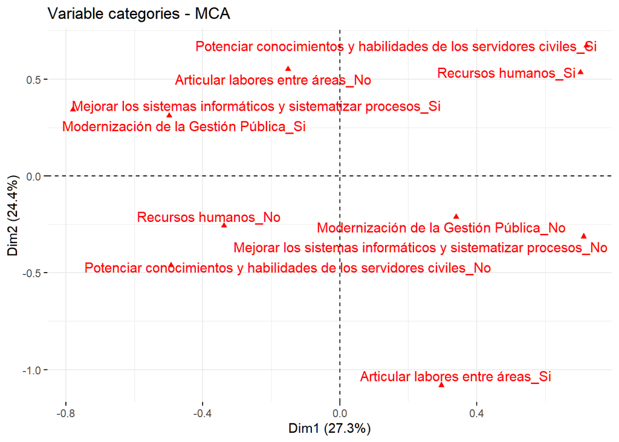

```r
fviz_mca_var(res.mca, repel = TRUE, ggtheme = theme_minimal())
```

Los que si marcaron “Potenciar conocimientos y habilidades de los servidores civiles” y “recursos humanos” tienen un perfil similar.

### Calidad de la representacion

cos2 mide el grado de asociacion entre la categoria de la variable y el eje particular.

```r
var$cos2
```

```
##                                                                         Dim 1
## Recursos humanos_Si                                                0.23810323
## Recursos humanos_No                                                0.23810323
## Modernización de la Gestión Pública_Si                             0.16941940
## Modernización de la Gestión Pública_No                             0.16941940
## Potenciar conocimientos y habilidades de los servidores civiles_Si 0.35538336
## Potenciar conocimientos y habilidades de los servidores civiles_No 0.35538336
## Articular labores entre áreas_Si                                   0.04481597
## Articular labores entre áreas_No                                   0.04481597
## Mejorar los sistemas informáticos y sistematizar procesos_Si       0.55561347
## Mejorar los sistemas informáticos y sistematizar procesos_No       0.55561347
##                                                                         Dim 2
## Recursos humanos_Si                                                0.13799779
## Recursos humanos_No                                                0.13799779
## Modernización de la Gestión Pública_Si                             0.06614067
## Modernización de la Gestión Pública_No                             0.06614067
## Potenciar conocimientos y habilidades de los servidores civiles_Si 0.31042596
## Potenciar conocimientos y habilidades de los servidores civiles_No 0.31042596
## Articular labores entre áreas_Si                                   0.59638506
## Articular labores entre áreas_No                                   0.59638506
## Mejorar los sistemas informáticos y sistematizar procesos_Si       0.10721518
## Mejorar los sistemas informáticos y sistematizar procesos_No       0.10721518
##                                                                         Dim 3
## Recursos humanos_Si                                                0.04740702
## Recursos humanos_No                                                0.04740702
## Modernización de la Gestión Pública_Si                             0.66994882
## Modernización de la Gestión Pública_No                             0.66994882
## Potenciar conocimientos y habilidades de los servidores civiles_Si 0.10430856
## Potenciar conocimientos y habilidades de los servidores civiles_No 0.10430856
## Articular labores entre áreas_Si                                   0.08623782
## Articular labores entre áreas_No                                   0.08623782
## Mejorar los sistemas informáticos y sistematizar procesos_Si       0.06391252
## Mejorar los sistemas informáticos y sistematizar procesos_No       0.06391252
##                                                                         Dim 4
## Recursos humanos_Si                                                0.55241663
## Recursos humanos_No                                                0.55241663
## Modernización de la Gestión Pública_Si                             0.05609506
## Modernización de la Gestión Pública_No                             0.05609506
## Potenciar conocimientos y habilidades de los servidores civiles_Si 0.05397752
## Potenciar conocimientos y habilidades de los servidores civiles_No 0.05397752
## Articular labores entre áreas_Si                                   0.15016001
## Articular labores entre áreas_No                                   0.15016001
## Mejorar los sistemas informáticos y sistematizar procesos_Si       0.07840676
## Mejorar los sistemas informáticos y sistematizar procesos_No       0.07840676
##                                                                         Dim 5
## Recursos humanos_Si                                                0.02407532
## Recursos humanos_No                                                0.02407532
## Modernización de la Gestión Pública_Si                             0.03839604
## Modernización de la Gestión Pública_No                             0.03839604
## Potenciar conocimientos y habilidades de los servidores civiles_Si 0.17590460
## Potenciar conocimientos y habilidades de los servidores civiles_No 0.17590460
## Articular labores entre áreas_Si                                   0.12240115
## Articular labores entre áreas_No                                   0.12240115
## Mejorar los sistemas informáticos y sistematizar procesos_Si       0.19485207
## Mejorar los sistemas informáticos y sistematizar procesos_No       0.19485207
```

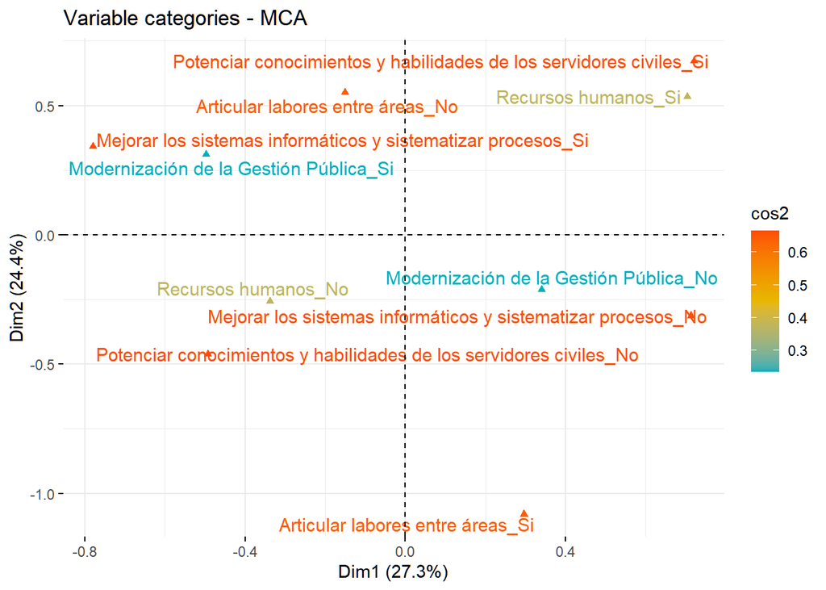

```r
fviz_mca_var(res.mca, col.var = "cos2", gradient.cols = c("#00AFBB", "#E7B800", "#FC4E07"), repel = TRUE, ggtheme =theme_minimal())
```

cos2 de las categorias con todas las dimensiones

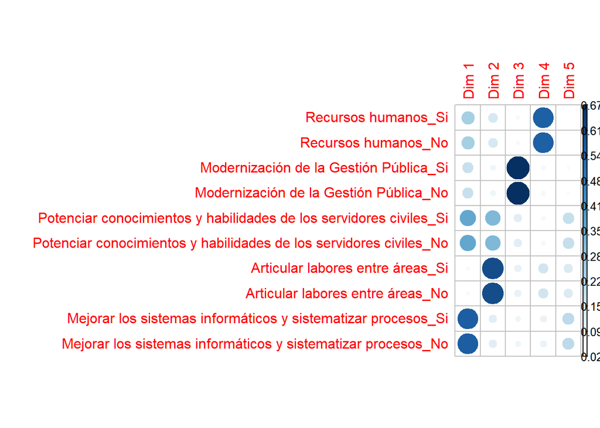

```r
corrplot(var$cos2, is.corr = FALSE)
```

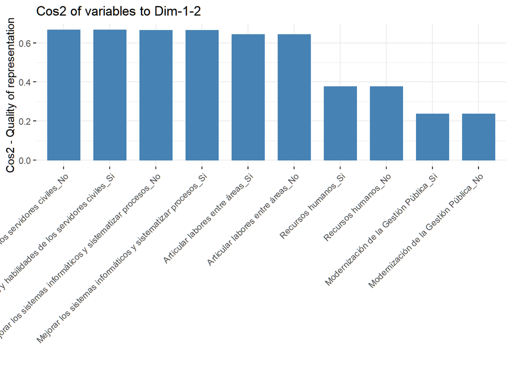

```r
fviz_cos2(res.mca, choice = "var", axes = 1:2)
```

Las variables mejor representadas en las 2 dimensiones son “Potenciar conocimientos y habilidades de los servidores civiles”, “Mejorar los sistemas informaticos y sistematizar procesos” y “articular labores entre areas”.

Probablemente sea necesario trabajar con las dimensiones 3 y 4 para trabajar con las variables “Modernizacion de la gestion publica” y “Recursos humanos”.

Anteriormente comentamos que los que si marcaron “Potenciar conocimientos y habilidades de los servidores civiles” y “recursos humanos” tienen un perfil similar, pero viendo que la representacion de la variable recursos humanos es baja entonces se descarta esa associacion.

### Contribucion de las categorias a las dimensiones 1 y 2

```r
var$contrib
```

```
##                                                                        Dim 1
## Recursos humanos_Si                                                11.788003
## Recursos humanos_No                                                 5.676755
## Modernización de la Gestión Pública_Si                              7.386202
## Modernización de la Gestión Pública_No                              5.040630
## Potenciar conocimientos y habilidades de los servidores civiles_Si 15.472553
## Potenciar conocimientos y habilidades de los servidores civiles_No 10.594646
## Articular labores entre áreas_Si                                    2.176079
## Articular labores entre áreas_No                                    1.111151
## Mejorar los sistemas informáticos y sistematizar procesos_Si       21.291696
## Mejorar los sistemas informáticos y sistematizar procesos_No       19.462285
##                                                                        Dim 2
## Recursos humanos_Si                                                 7.646168
## Recursos humanos_No                                                 3.682169
## Modernización de la Gestión Pública_Si                              3.227181
## Modernización de la Gestión Pública_No                              2.202353
## Potenciar conocimientos y habilidades de los servidores civiles_Si 15.125845
## Potenciar conocimientos y habilidades de los servidores civiles_No 10.357242
## Articular labores entre áreas_Si                                   32.408973
## Articular labores entre áreas_No                                   16.548699
## Mejorar los sistemas informáticos y sistematizar procesos_Si        4.598228
## Mejorar los sistemas informáticos y sistematizar procesos_No        4.203142
##                                                                        Dim 3
## Recursos humanos_Si                                                 3.292584
## Recursos humanos_No                                                 1.585611
## Modernización de la Gestión Pública_Si                             40.974997
## Modernización de la Gestión Pública_No                             27.962919
## Potenciar conocimientos y habilidades de los servidores civiles_Si  6.370948
## Potenciar conocimientos y habilidades de los servidores civiles_No  4.362431
## Articular labores entre áreas_Si                                    5.874336
## Articular labores entre áreas_No                                    2.999559
## Mejorar los sistemas informáticos y sistematizar procesos_Si        3.435917
## Mejorar los sistemas informáticos y sistematizar procesos_No        3.140699
##                                                                        Dim 4
## Recursos humanos_Si                                                41.844600
## Recursos humanos_No                                                20.151126
## Modernización de la Gestión Pública_Si                              3.741799
## Modernización de la Gestión Pública_No                              2.553548
## Potenciar conocimientos y habilidades de los servidores civiles_Si  3.595635
## Potenciar conocimientos y habilidades de los servidores civiles_No  2.462068
## Articular labores entre áreas_Si                                   11.155622
## Articular labores entre áreas_No                                    5.696294
## Mejorar los sistemas informáticos y sistematizar procesos_Si        4.597151
## Mejorar los sistemas informáticos y sistematizar procesos_No        4.202158
##                                                                        Dim 5
## Recursos humanos_Si                                                 2.924588
## Recursos humanos_No                                                 1.408396
## Modernización de la Gestión Pública_Si                              4.107355
## Modernización de la Gestión Pública_No                              2.803017
## Potenciar conocimientos y habilidades de los servidores civiles_Si 18.791427
## Potenciar conocimientos y habilidades de los servidores civiles_No 12.867205
## Articular labores entre áreas_Si                                   14.582935
## Articular labores entre áreas_No                                    7.446352
## Mejorar los sistemas informáticos y sistematizar procesos_Si       18.321464
## Mejorar los sistemas informáticos y sistematizar procesos_No       16.747260
```

Contribuciones de las categorias a la dimension 1

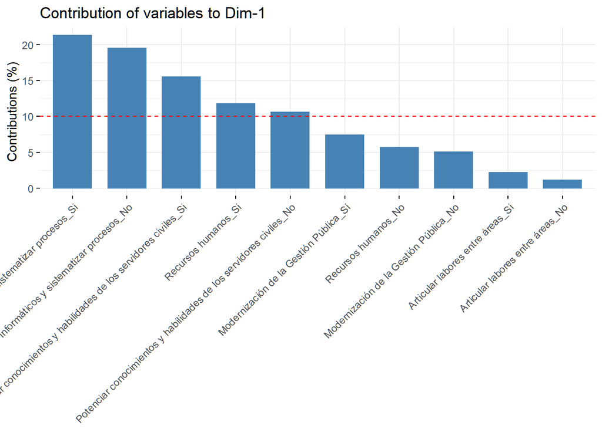

```r
fviz_contrib(res.mca, choice = "var", axes = 1)
```

La variable “Mejorar los sistemas informaticos y sistematizar procesos” y la categoria si de la variable “Potenciar conocimientos y habilidades de los servidores civiles” son los mas importantes de la dimension 1.

Contribuciones de las categorias a la dimension 2

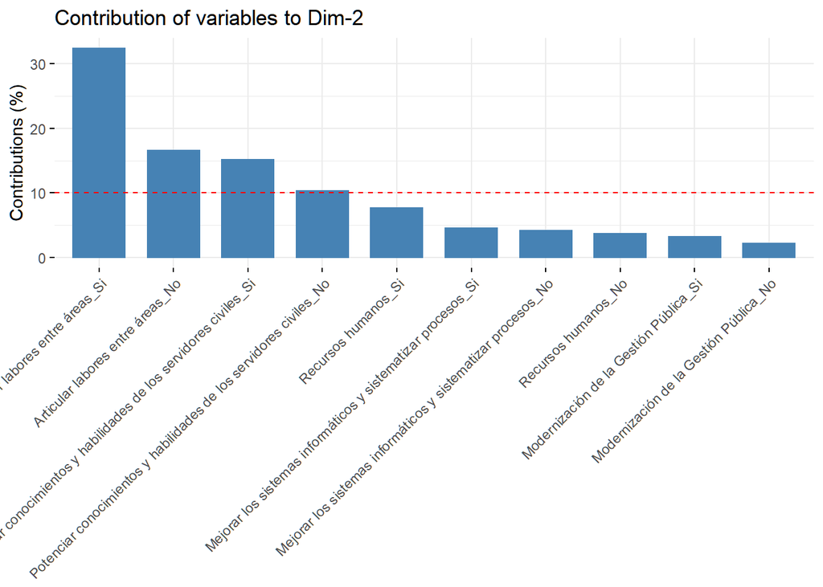

```r
fviz_contrib(res.mca, choice = "var", axes = 2)
```

La variable “articular labores entre areas” y la categoria si de “Potenciar conocimientos y habilidades de los servidores civiles” son los mas importantes de la variable 2

Contribuciones de las categorias a las dimensiones 1 y 2

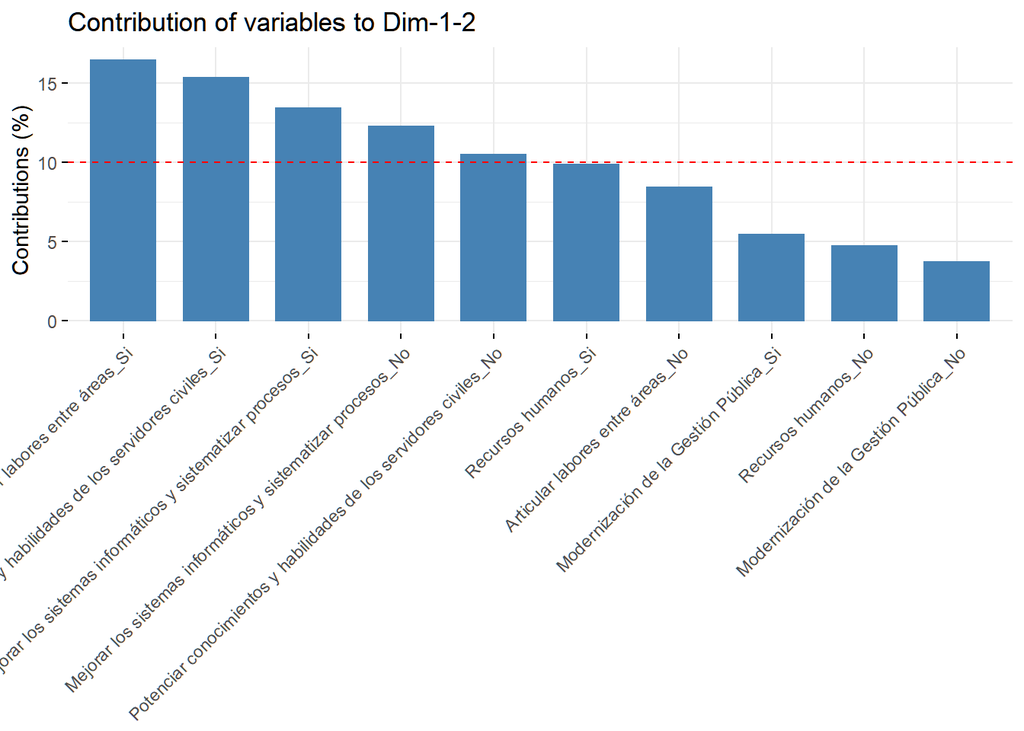

```r
fviz_contrib(res.mca, choice = "var", axes = 1:2)
```

Las caegorias si de “articular labores entre areas” y “Potenciar conocimientos y habilidades de los servidores civiles” son los mas importantes en explicar la variabilidad en los datos que estamos trabajando

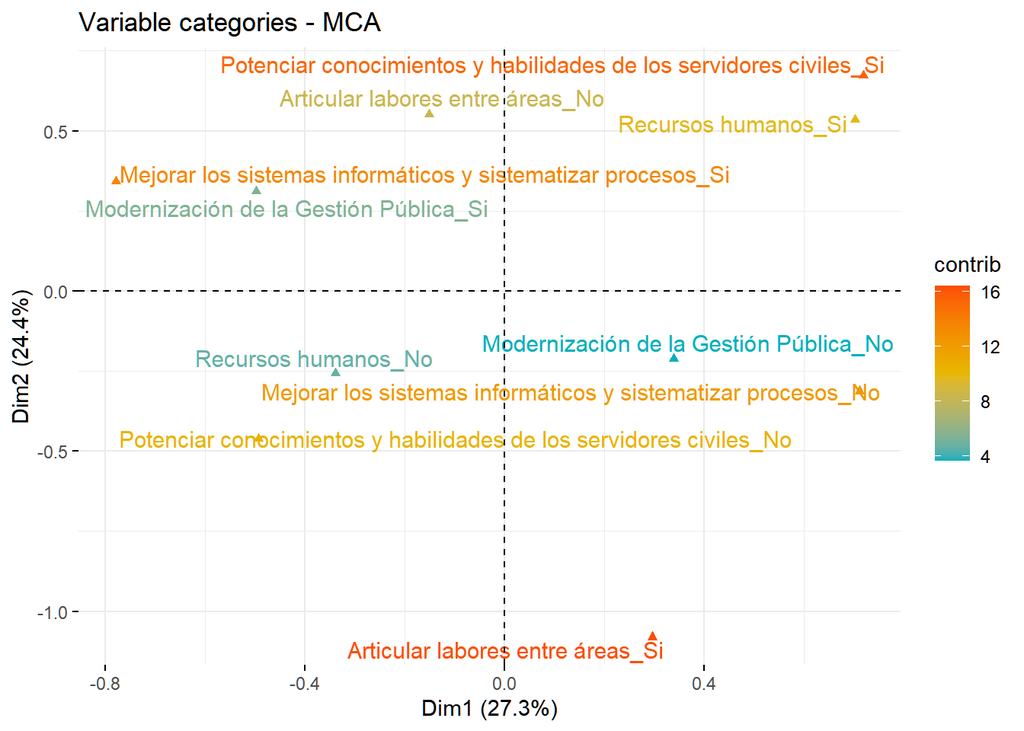

```r
fviz_mca_var(res.mca, col.var = "contrib", gradient.cols = c("#00AFBB", "#E7B800", "#FC4E07"), repel = TRUE, ggtheme = theme_minimal())
```

## Grafico de individuos

```r
ind <- get_mca_ind(res.mca)
ind
```

```
## Multiple Correspondence Analysis Results for individuals
##  ===================================================
##   Name       Description
## 1 "$coord"   "Coordinates for the individuals"
## 2 "$cos2"    "Cos2 for the individuals"
## 3 "$contrib" "contributions of the individuals"
```

Parte de las coordenadas de puntos, calidad de la representacion y contribuciones de los individuos

```r
head(ind$coord)
```

```
##         Dim 1      Dim 2       Dim 3      Dim 4       Dim 5
## 1  0.49148490  0.1790358 -0.04668557 -0.7280886  0.06261353
## 2  0.02661403 -0.2805972 -0.34498566 -0.5039900 -0.44969458
## 3  0.49148490  0.1790358 -0.04668557 -0.7280886  0.06261353
## 4 -0.12304809 -0.7298713  0.69286978  0.1126362 -0.24538891
## 5  0.02661403 -0.2805972 -0.34498566 -0.5039900 -0.44969458
## 6  0.59703856 -0.6207408 -0.27423682  0.6358876 -0.20470906
```

```r
head(ind$cos2)
```

```
##         Dim 1      Dim 2       Dim 3      Dim 4       Dim 5
## 1 0.298283751 0.03958119 0.002691378 0.65460256 0.004841117
## 2 0.001081898 0.12026281 0.181788673 0.38797933 0.308887286
## 3 0.298283751 0.03958119 0.002691378 0.65460256 0.004841117
## 4 0.013754088 0.48392120 0.436099215 0.01152492 0.054700580
## 5 0.001081898 0.12026281 0.181788673 0.38797933 0.308887286
## 6 0.282175481 0.30502479 0.059534133 0.32009230 0.033173297
```

```r
head(ind$contrib)
```

```
##          Dim 1       Dim 2       Dim 3       Dim 4        Dim 5
## 1 2.395636e-02 0.003557761 0.000303239 0.080438984 0.0009540132
## 2 7.024603e-05 0.008739040 0.016558527 0.038542685 0.0492099988
## 3 2.395636e-02 0.003557761 0.000303239 0.080438984 0.0009540132
## 4 1.501586e-03 0.059127523 0.066791755 0.001925103 0.0146530460
## 5 7.024603e-05 0.008739040 0.016558527 0.038542685 0.0492099988
## 6 3.535128e-02 0.042767880 0.010463359 0.061356251 0.0101974637
```

### Calidad de los individuos

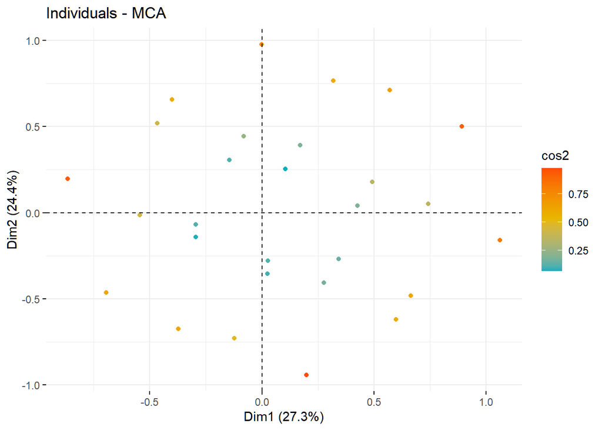

```r
fviz_mca_ind(res.mca, col.ind = "cos2", label = "none", gradient.cols = c("#00AFBB", "#E7B800", "#FC4E07"), repel = TRUE, ggtheme = theme_minimal())
```

Top 20 individuos que mas aportan a la calidad de las dimensiones 1 y 2

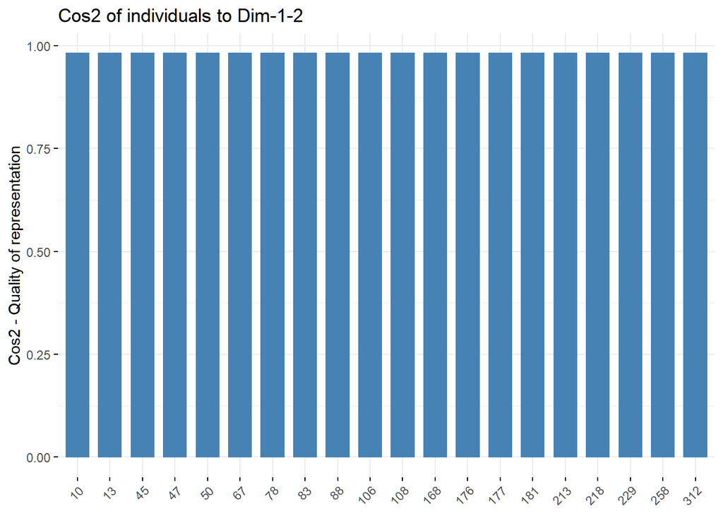

```r
fviz_cos2(res.mca, choice = "ind", axes = 1:2, top = 20)
```

### Contribucion de los individuos

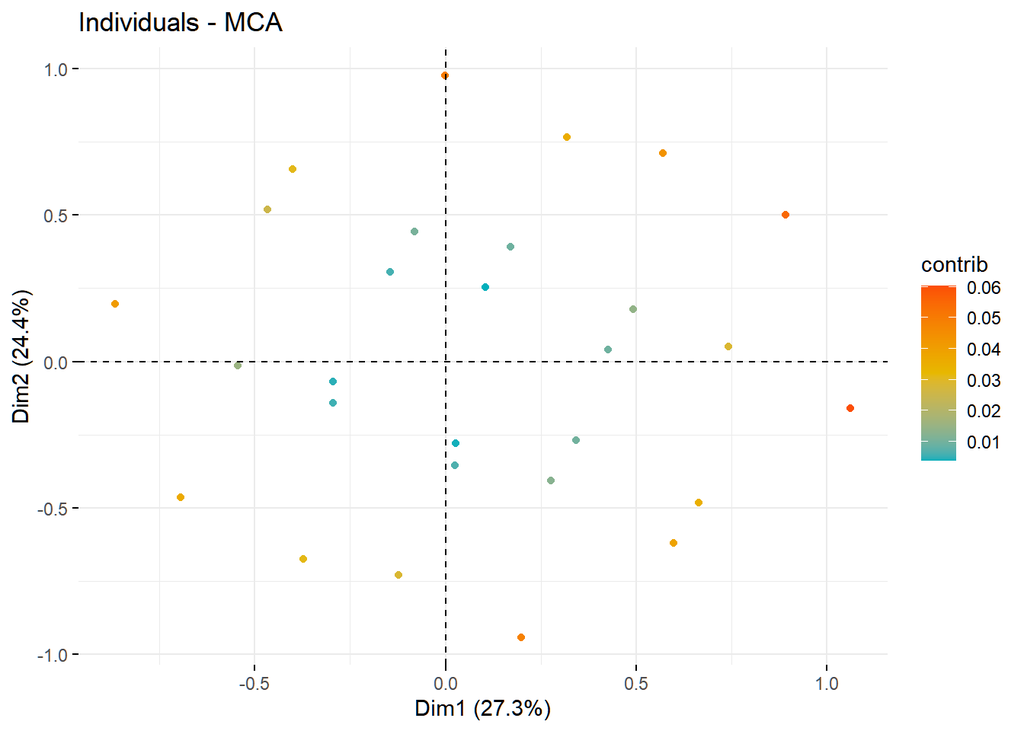

```r
fviz_mca_ind(res.mca, col.ind = "contrib", label = "none", gradient.cols = c("#00AFBB", "#E7B800", "#FC4E07"), repel = TRUE, ggtheme = theme_minimal())
```

Top 20 individuos que mas contribuyen a las dimensiones 1 y 2

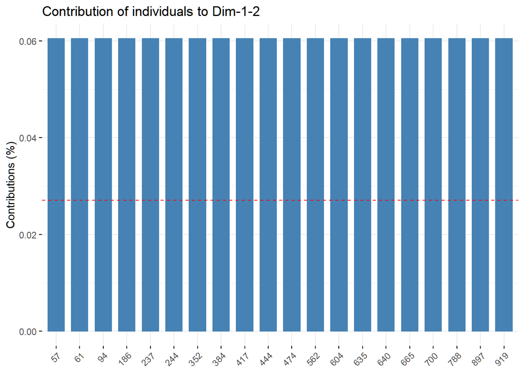

```r
fviz_contrib(res.mca, choice = "ind", axes = 1:2, top = 20)
```